# Workshop 10 - Data Viz 3

Seth Redmond

## 1. Introduction

After the last two workshops you should have a good range of tricks up your sleeve for making graphs and making them look pretty. So for this last data viz workshop we’re going to spend a bit less time on actual coding, and a bit more time thinking about how to identify a good story in your data, and then how to make your data tell that story.

Load in these three libraries, you’re going to need them:

```r
library(tidyverse)
library(RColorBrewer)
library(patchwork)
```

## 2. Summary Tables

In the tidy data sessions you learned how to: import and tidy the beetles dataset; remove all the automatic ’X columns; pivot species names; and separate the spp column into genus and species.

Let’s do all that again to get a nice clean beetles table. Oh, except I’ve left out the pivot command here because I’m going to be like that today.

**Fill in the required pivot command so that the columns are ‘spp’ and ‘count’**

```r
beetles <- read.csv("dung_beetles.csv") %>%
  rename_with(tolower, everything()) %>%
  select(!starts_with("X")) %>%
  rename_with( ~ gsub("opis", "opris", .x), matches("Copis")) %>%
    # <-- PIVOT COMMAND GOES HERE
  separate_wider_delim("spp", "_",
                       names = c("genus",
                                 "species"))
```

### Group By / Summarise

OK, now we have a nice clean table with the genius and species names separate, we can start to look for some broad patterns in the data. What about seasonality?

Not only can we use ‘mutate’ to make calculations ‘horizontally’ across columns, but we can also make calculations ‘vertically’ by grouping rows together and making summary statistics for each group.

It will not shock you to learn that these functions are called ‘group_by’ and ‘summarize’. Go take a look at their help files now…

If you run the first of these, ‘group_by’, the output looks *almost* the same, but this time the table has added an underlying flag to say that it can be grouped by month.

```r
beetles %>%
  group_by(month)
```

```
## # A tibble: 1,320 × 5
## # Groups:   month [11]
##     site month   genus       species        count
##    <int> <chr>   <chr>       <chr>          <int>
##  1     1 January caccobius   bawangensis        0
##  2     1 January catharsius  dayacus            5
##  3     1 January catharsius  renaudpauliani     8
##  4     1 January copris      agnus              0
##  5     1 January copris      ramosiceps         0
##  6     1 January copris      sinicus            9
##  7     1 January microcopris doriae             1
##  8     1 January microcopris hidakai            0
##  9     1 January onthophagus hidakai            0
## 10     1 January onthophagus liliputanus        0
## # ℹ 1,310 more rows
```

It is when you add this to a summarize function that an operation such as ‘sum’ can be applied to those groups.

Let’s see this in action. Group by the months and count all of them up as follows:

```r
total_pcm <- beetles %>%
  group_by(month) %>%
  summarize(total = sum(count))
```

**Now try plotting that with ggplot as a bar plot**

**You’ll need to reorder the months so they’re in the proper order**

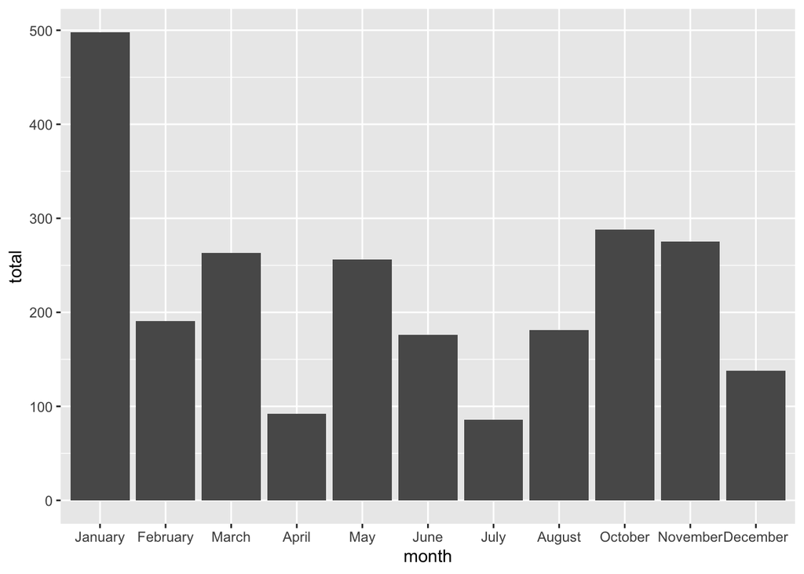

hmmm, there *could* be something there, but it’s not clear. Maybe we need to look at each genus separately to see if it’s dominated by one signal?

## 3. Heatmaps

A bar plot isn’t the best option to use here, so we’re going to make a simple heatmap. Heatmaps are an excellent way to look at the interaction of three variables - particularly if were looking at occurrence data like we are here.

There are a few ways to do this in R and ggplot, but we’re going to use geom_raster.

**group the beetles table by genus name as well as month. Plot all of these together using geom_raster**

**note, you’ll need to use themes to fit those month names in properly**

**your plot should look like this:**

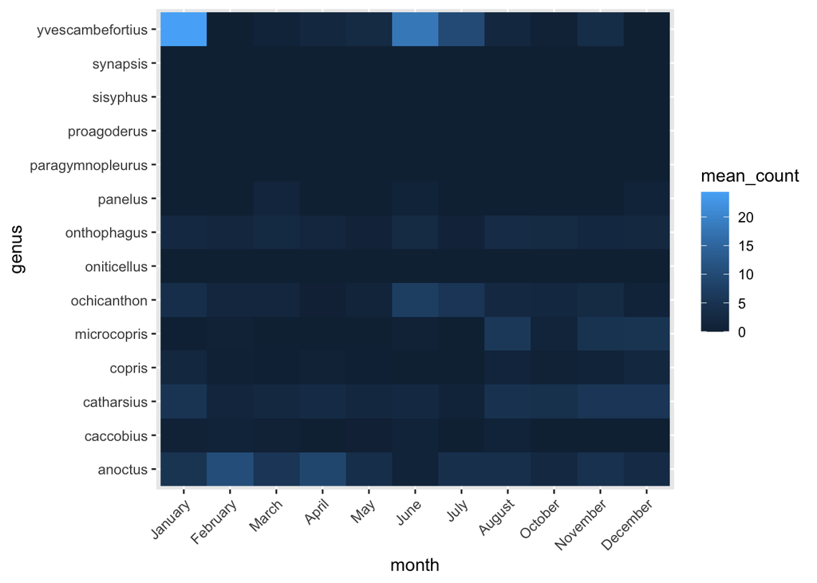

### Setting scale limits

OK, now we’re starting to get a good overview of the number of beetles per month but the signal is dominated by the January bonanza of ‘yvescambefortius’.

To deal with this in a quick-and-dirty way, let’s just cut that scale off at ten. You’ll need to set up a scale for ‘fill’ with a top limit of 10. This will remove all values over ten.

#### Tip:

- To make it look nice, set the missing values to the default color for ‘max’  
  (this is a light blue with the hex code: #56B1F7)

**limit your scales so your plot looks like this:**

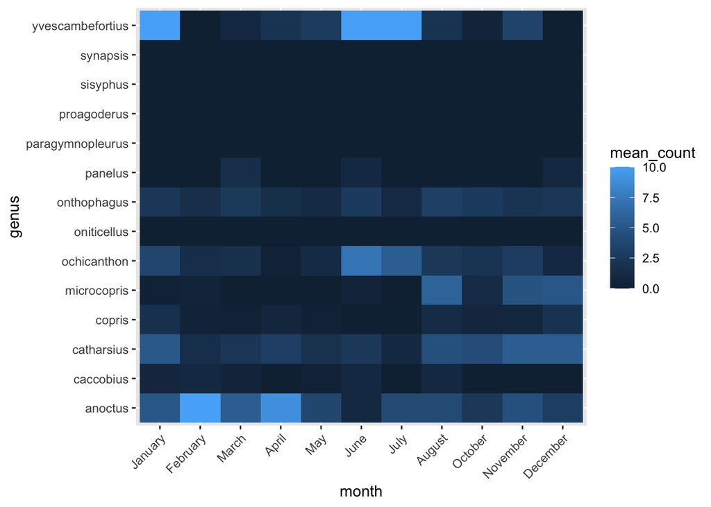

#### Extra Credit:

If we really wanted to look a seasonality, the proper way to deal with this would be to normalise (divide) all our samples by the mean count for that genus.

To do this you’ll need to make a table summing up all the mean per-month values; merge it with the main table; and divide the original means by this total.

**if you’re feeling keen; try and make this plot:**

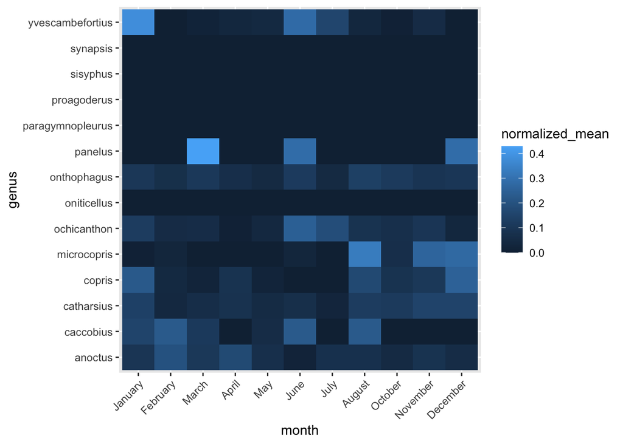

This isn’t by any means a publication quality figure, but it is starting to show you some of the patterns that are present in this dataset you’ve been working with for a few months now.

This is often the first step in your exploratory data analysis - the rapid plots you will put together to see what shape your data is in and what further analyses you might want to focus on.

## 4. Axes

OK, let’s look at a new data set.

https://ourworldindata.org/guinea-worm-path-eradication

This comes from ‘our world in data’ and concerns the campaign to eliminate Guinea Worm, a devastating parasitic disease that was largely neglected by the western world until it became the primary focus of the [Carter Center](https://www.cartercenter.org/health/guinea_worm/) who have been working to eliminate it for the last four decades.

Data is given for individual countries, as well as the worldwide total. Lets take a look at the totals first:

```r
guinea_world <- read.csv("number-of-reported-guinea-worm-dracunculiasis-cases.csv") %>%
              rename(cases = Reported.cases.of.Guinea.worm.disease,
                     country = Entity) %>%
              rename_with(tolower) %>%
              filter(country == "World")
```

**Plot this with both a geom_line and geom_point, so that it looks like this:**

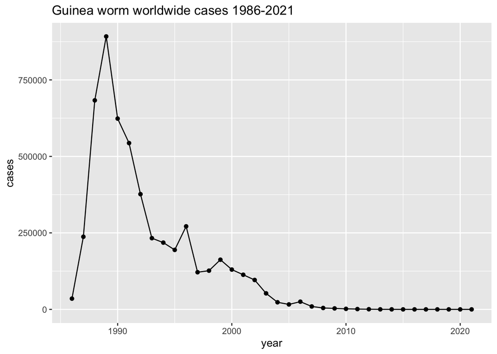

### Log Scales

Woohoo! this is going well. Guinea worm cases have plummeted to the point where they are… low? *how low*?

This is a problem you’ll encounter a lot; a y-axis with extremely large ranges which cannot easily be shown on the same scale. One answer to this is to use a logarithmic scale - instead of scaling linearly, this means each point up the y axis will be a factor of the one before (e.g. 10, 100, 1000…).

**Look through the available y axis scales and replace the default scale so your plot looks like this:**

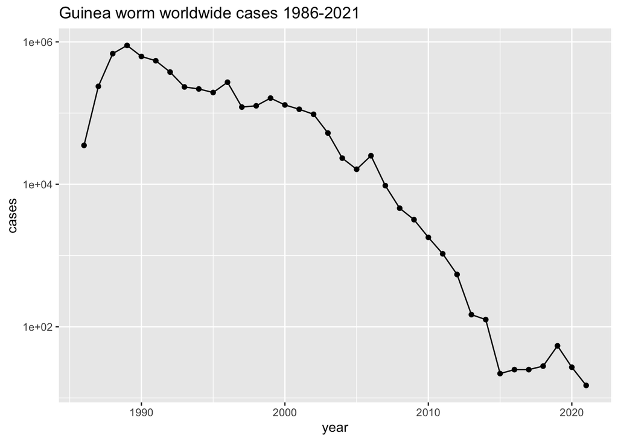

### Limits

OK, looking better, but that log scale seems to stop at 10; that could be confusing.

Use the limits variable in your log scale to make your scale run from 1 to 1 million  
(note, log scales *cannot* show zero - as there is no defined logarithm of zero)

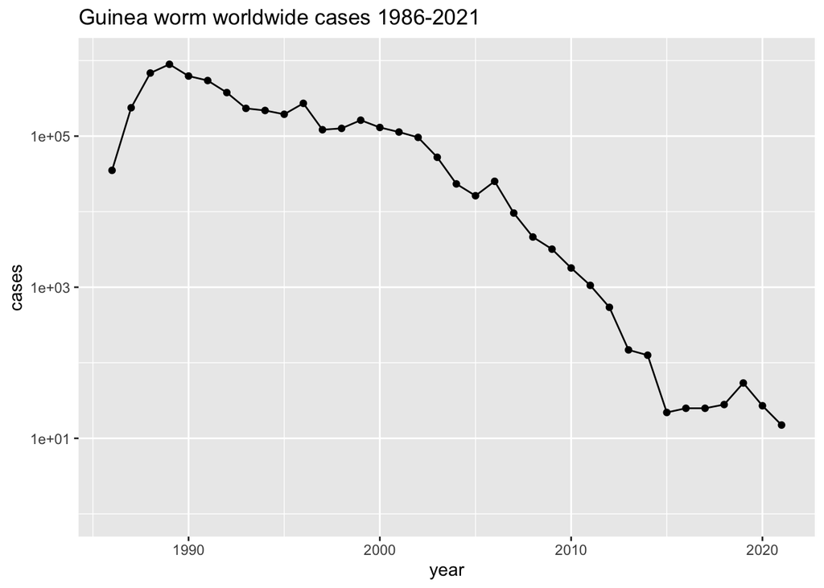

### Breaks

*ggplot* has defaulted to using scientific notation for this log scale so it reads as, eg, 1e+03 instead of 1000. This is perfectly correct, but we can make this a little more “human readable” by setting ‘breaks’ for our scale: this tells ggplot where to put in an axis marker and, if we give it labels, what to call them.

**your final plot should look like this:**

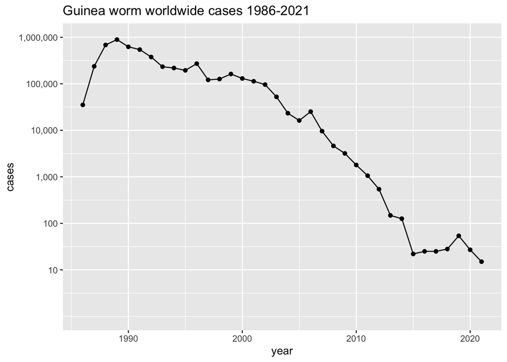

## 5. Finding a Story to Tell

Now let’s continue this exploratory analysis by looking at case counts in the countries themselves.

*Nb: I’m going to manually replace one of the longer country names with an abbreviation to make it easier to plot*

```r
guinea_countries <- read.csv("number-of-reported-guinea-worm-dracunculiasis-cases.csv") %>%
              rename(cases = Reported.cases.of.Guinea.worm.disease,
                     country = Entity) %>%
              rename_with(tolower) %>%
              mutate(country = gsub("Central African Republic",
                                    "C.A.R.",
                                    country)) %>%
              filter(country != "World")
```

We’re going to limit this to the countries that have *any* cases of guinea worm. I’ve pulled these out of the table for you and ordered them by total cases. Let’s use them to order a factor of the country names

```r
endemic_countries <- c("Angola","C.A.R.","Kenya","Yemen",
                        "Pakistan","Chad","Cameroon","Senegal","Ethiopia",
                        "Mauritania","Cote d'Ivoire","Mali","Togo","India",
                        "Benin","Niger","Burkina Faso","Uganda","Ghana",
                        "Sudan","South Sudan","Nigeria")

guinea_countries <- guinea_countries %>% filter(country %in% endemic_countries)

guinea_countries$country <- factor(guinea_countries$country,levels=endemic_countries)
```

#### Extra Credit:

**how would you get these countries from the table using dplyr and tidyr?**

**First plot these with a bar plot, using geom_col, coloured by country:**

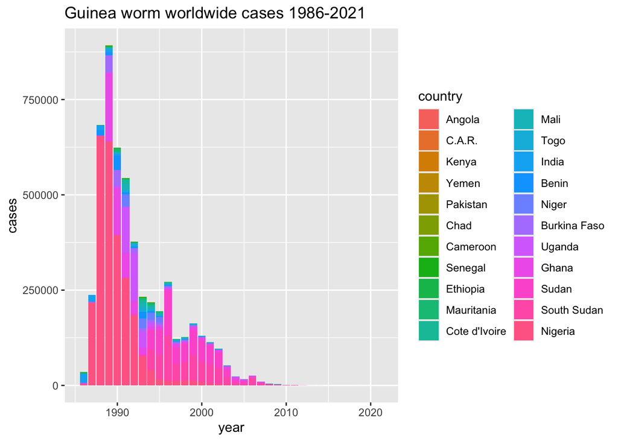

It looks like these case counts are dominated by a few countries, but it is hard to see with all those colours.

Let’s look at just the high burden countries, those with more than 100,000 cases ever.

```r
high_burden_countries <- c("Burkina Faso","Ghana","Niger","Nigeria",
                           "South Sudan","Sudan","Uganda")
```

#### Extra Credit:

I made this list of countries using group_by and summarize to pull out the total cases ever; then added a ‘filter’ statement and used ‘pull’ to get the country names themselves.

**Try making the high_burden_countries vector yourself**

### Highlighting a subset of your data

We can see in the following plot that these countries represent the vast majority of Guinea worm cases ever. But which countries?

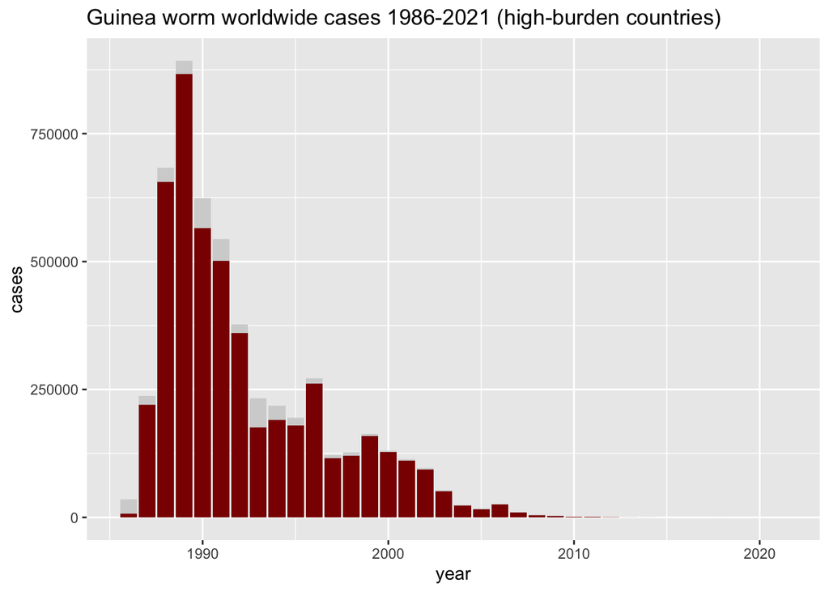

```r
ggplot(guinea_countries,aes(year,cases,group=country)) +
  geom_col(fill="light grey") +
  geom_col(fill="dark red",
           data=guinea_countries %>% filter(country %in% high_burden_countries)) +
  ggtitle("Guinea worm worldwide cases 1986-2021 (high-burden countries)")
```

**fix the code above so that it colours *only* the high-burden countries, like this:**

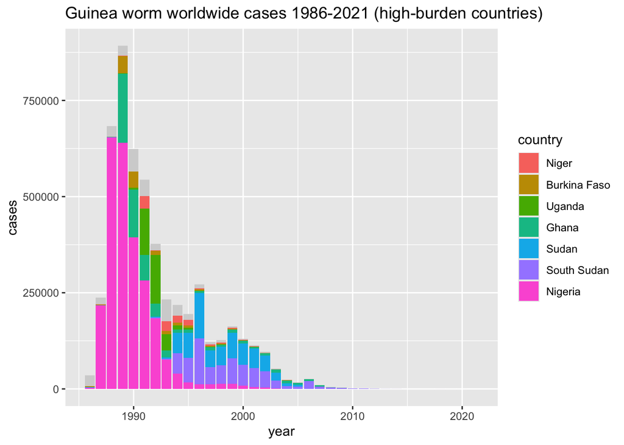

Great, so what has happened since 2013, after transmission drops to about 100 a year? Let’s use ‘xlim’ to look at just at those later years.

*Nb: Because of a quirk in how ggplot plots bars, you’ll have to set your limits at 2012.5, not 2013*

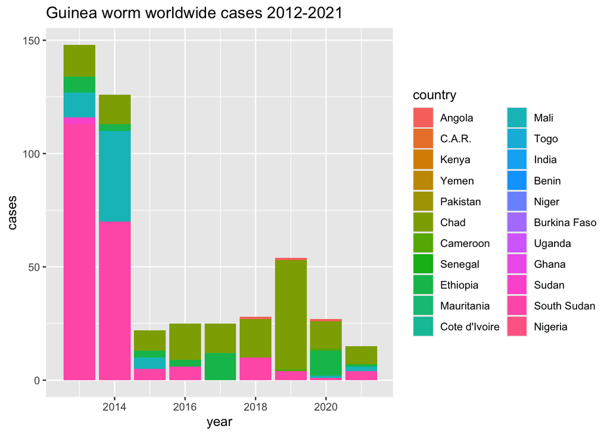

```r
ggplot(guinea_countries,aes(year,cases,group=country,fill=country)) +
  geom_col() + xlim(2012.5,NA)+
  ggtitle("Guinea worm worldwide cases 2012-2021")
```

It seems like these are a very different set of countries. Let’s look at only those countries:

```r
# countries with any cases after 2011
persistent_countries <- c("Angola","Cameroon","Chad","Ethiopia",
                          "Mali","South Sudan","Sudan")
```

#### Extra Credit:

**Again, if you’re keen, see if you can recreate this list. This time you’re going to use filter, pull, and unique**

## 6. Telling Your Story Well

OK, so we have a clear story to tell with this data: Previous high burden countries have eliminated Guinea worm, while a new set of countries show persistent transmission.

How do we show this in one plot? We want to show individual countries, but we want to group them into two broad categories. There’s lots of ways to do this, but we’re going to use a custom colour scale.

### Using Manual Colour Scales to Tell Your Story

Go look at the help page for ‘scale_fill_manual’ or ‘scale_color_manual’

First we need to set up a vector of default colours - we’re going to make them all grey

```r
gwcols <- rep("grey",length(endemic_countries))
names(gwcols) <- endemic_countries
```

Now, you can pull out individual scales from the brewer package you were using last week using “brewer.pal”. You can look through all the available palettes here: https://colorbrewer2.org/

Here’s how I’ve done it for the remaining countries (I’ve removed the ones that are also high-burden countries)

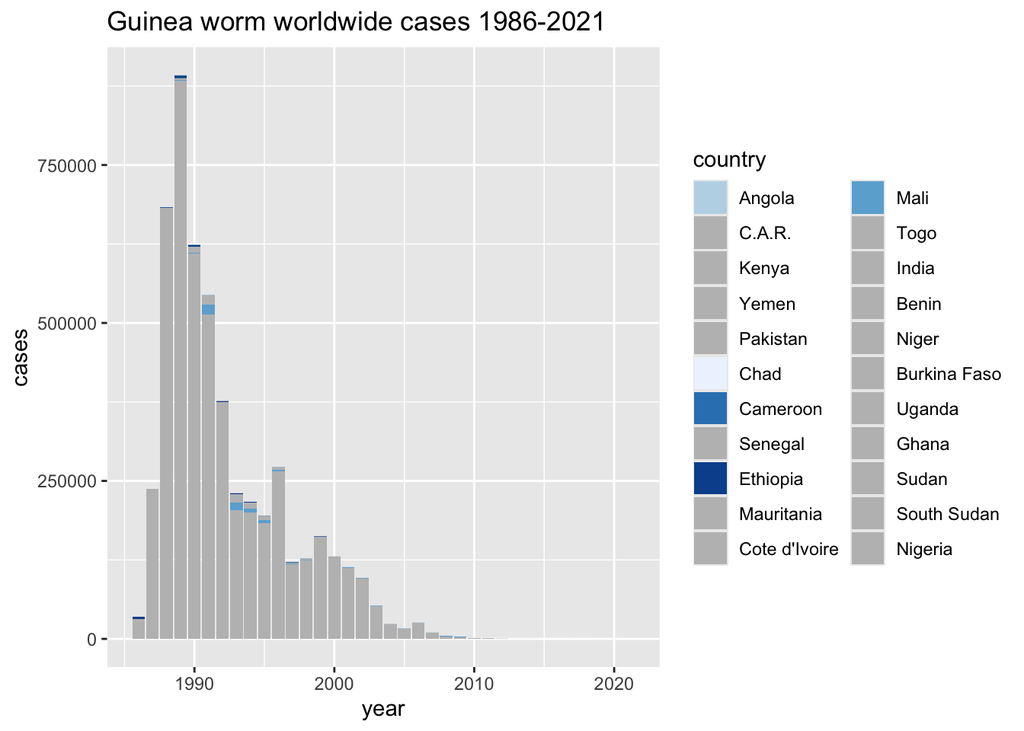

```r
#remove persistent countries that are also high-burden countries
persistent_countries <- persistent_countries[!persistent_countries %in% high_burden_countries]

#get a vector of 'blues' the same length as persistent_countries:
blues <- brewer.pal(length(persistent_countries),name="Blues")

#shuffle blue colours so similar colours aren't next to each other
blues <- sample(blues)

#assign blue colours to gwcols
gwcols[persistent_countries] <- blues

#view our plot with the
ggplot(guinea_countries,aes(year,cases,group=country,fill=country)) +
  geom_col() +
  scale_fill_manual(values=gwcols) +
  ggtitle("Guinea worm worldwide cases 1986-2021")
```

**Now do the same for the high burden countries; Use the ‘Oranges’ scale**

**Remember to randomise the colours so similar colours aren’t plotted next to each other**

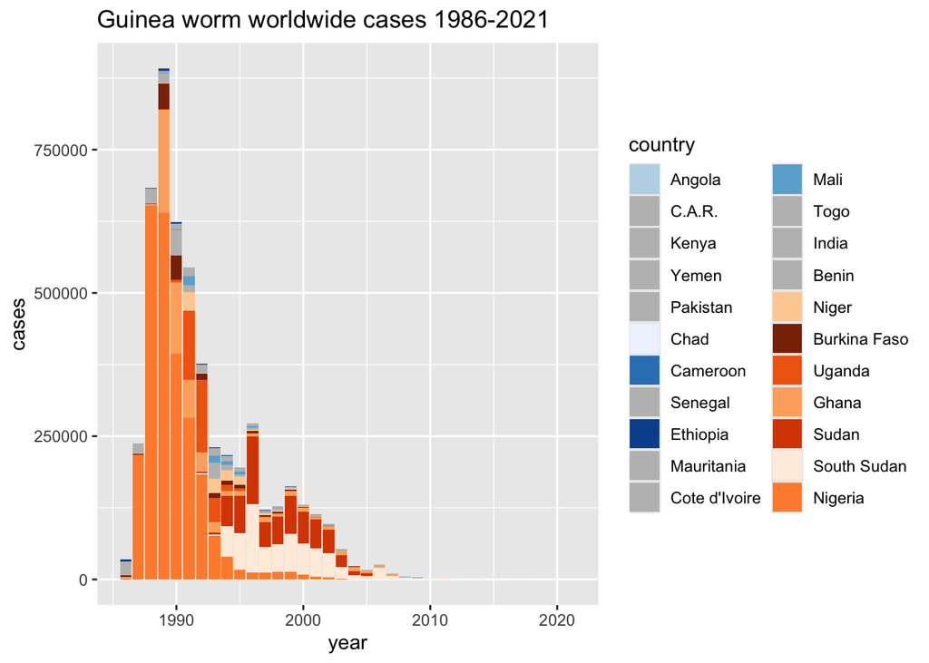

## 7. The Big Challenge:

#### Putting your three plots together.

**Make separate plots for the years 1986-2012 and 2013-2021**

**Plot these side by side, with the total (on your log scale) above**

**Collect all your legends together in one place**

#### Tips:

- Because of a quirk in how ggplot plots bars, you’ll have to set your limits at 2012.5, not 2012 or 2013)
- you can get rid of that annoying space around the plots if you use, eg scale_x_continuous with ‘expand=c(0,0,0,0)’ this sets the space that is put on all four axes of your plot
- check out plot_layout(guides=“collect”) and guide_area() to see how to put your guides all in the same place

**The end result should look something like this:**

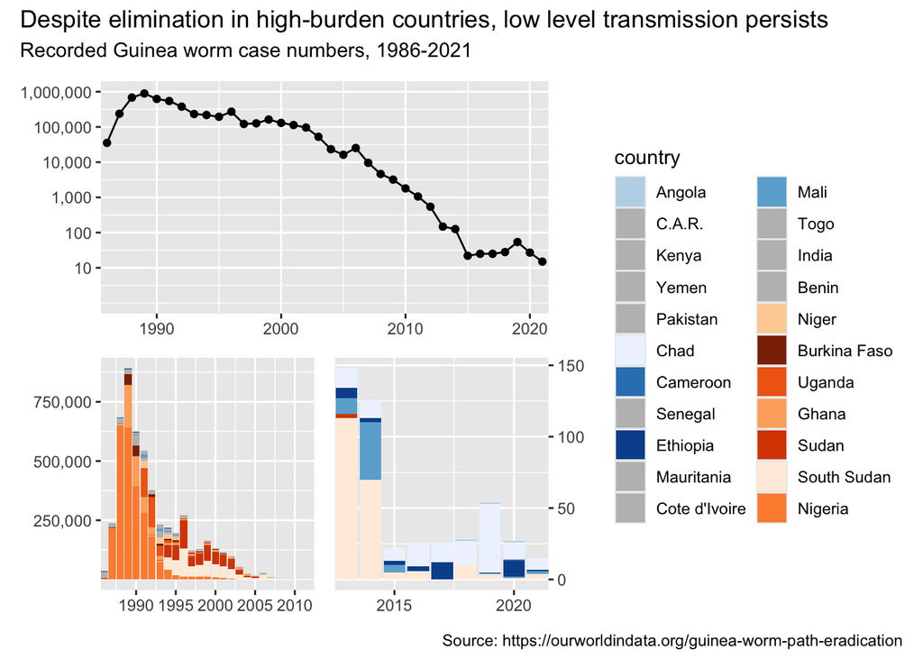

#### Extra Credit:

**can you use the plot_layout function to make your plot look like this?**

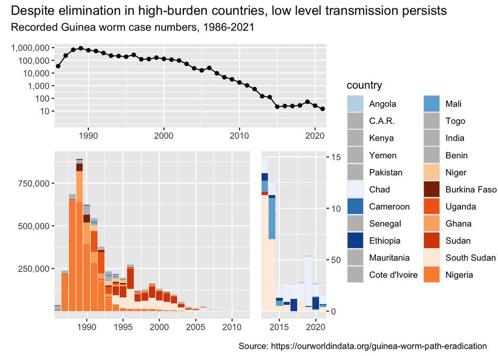